# Nor Hendra – Geospatial Analytics for Peace

## Geospatial Analytics for Peace

Nor Hendra  
ISSS626 Geospatial Analytics and Applications  
Take-home Exercise 2

*Data from ACLED and MIMU v9.4*  
*Myanmar, 1 January 2021 to 30 September 2025*

## Contents

1. **Research question**
2. **Study area and data**
3. **Analytical approach**
4. **Key finding: where**
5. **Key finding: how it evolved**
6. **Key finding: several wars, not one**
7. **Air war follows ground war (value-added)**
8. **Limitations**
9. **Public-safety implications**

## 1 · Research question

Where has armed conflict concentrated across Myanmar’s 330 townships since the February 2021 coup, and how has that pattern changed quarter by quarter?

Where, over the whole period

Which townships have more or fewer events than chance would give, and which stand apart from their neighbours?

→ *Local Moran’s I and Getis–Ord Gi* (LMSA)*

How it evolved

Which hot spots persisted, emerged or faded, and how fast did they spread?

→ *Emerging Hot Spot Analysis on a quarterly space-time cube*

Value added

Does the air war follow the ground war, or strike where there is little other fighting?

→ *Bivariate Local Moran’s I*

## 2 · Study area and data

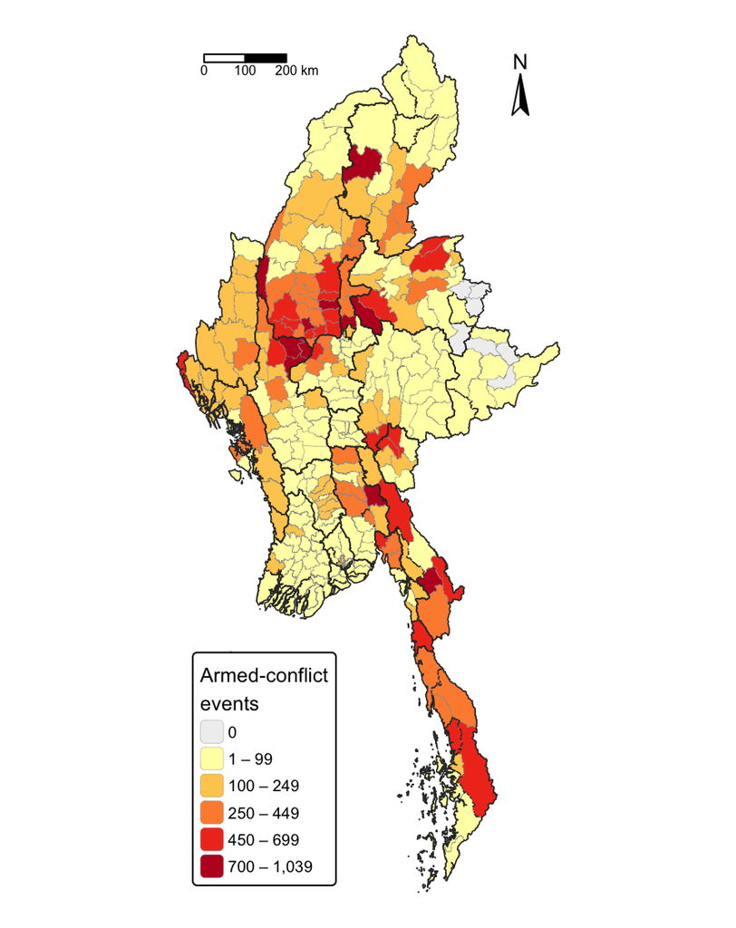

**The township is the unit.** All 330 MIMU v9.4 townships, projected to UTM 47N (EPSG:32647). Cocokyun, 126 km offshore with no neighbours, is left out of the local statistics, so 329 are analysed.

**Armed conflict means three ACLED event types:** battles, explosions/remote violence and violence against civilians. Protests, riots and strategic developments are excluded.

**Every event that drops out or moves is counted.** 180 events (0.3%) whose township name disagreed with their coordinates were reassigned across a shared boundary.

**87,109** raw ACLED records, January 2021 to September 2025  
↓ duplicates and offshore records removed (8)  
↓ keep the three armed-conflict event types (33,101 removed)  
↓ drop events located only to a region (93)  
**53,907 armed-conflict events** in 330 townships

## 3 · Analytical approach

1

**Gateway**

Is conflict clustered at all?

Global Moran’s I = 0.49, p = 0.001 (999 permutations)

*Clustering is real, so local statistics are justified*

2

**LMSA, whole period**

Where are the clusters, hot spots and outliers?

Local Moran’s I and Gi*, Queen contiguity with two island bridges

Re-run with KNN k = 6, log(1 + count) and FDR

3

**EHSA, 19 quarters**

How has each township’s status changed?

Gi* per quarter against that quarter’s own permutations, Mann–Kendall trend, rule-based classes

*`sfdep` corrected; six sensitivity runs*

4

**Value-added**

Does the air war follow the ground war?

Bivariate Local Moran’s I: air and drone strikes in a township against all other fighting around it

Every analytical choice (variable form, neighbours, weights, time bin, threshold) was screened against at least two alternatives before seeing the result. Close calls became the sensitivity runs, and maps show only townships significant at p < 0.05.

## 4 · Where: one core, many fronts

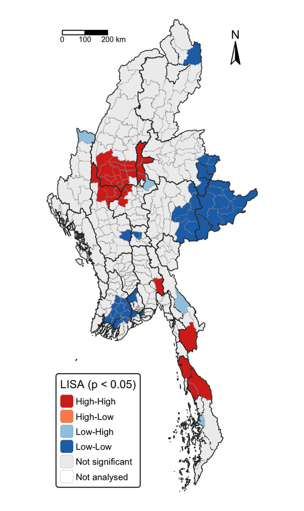

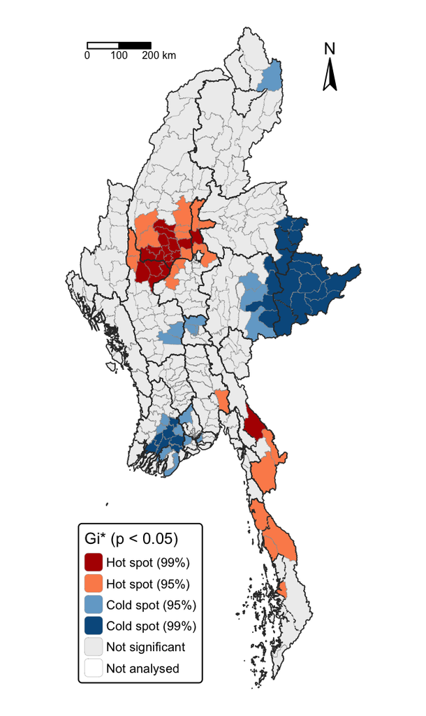

- 33 High-High townships, 28 of them one contiguous Dry Zone block in Sagaing, Magway and Mandalay; 49 Low-Low in Yangon, the delta, Nay Pyi Taw and the Shan hills.
- No High-Low outlier: heavy fighting never sits among quiet neighbours. 4 Low-High townships are quiet towns ringed by fighting, such as Pyinoolwin.
- Gi* finds 40 hot and 53 cold spots; 17 of the 18 hot spots at 99% confidence are in the Dry Zone core.
- 17 townships are hot under all four specifications, 16 in the Dry Zone: the most reliable whole-period result. 26 are cold under all four.
- Northern Shan and Rakhine, scene of the largest offensives since late 2023, are not hot over the whole period. Brief fighting is diluted in a 57-month total, which is why time is analysed next.

Only townships significant at p < 0.05 are coloured. Cold means few events were recorded, not that an area is safe.

## 5 · How it evolved: a lasting core

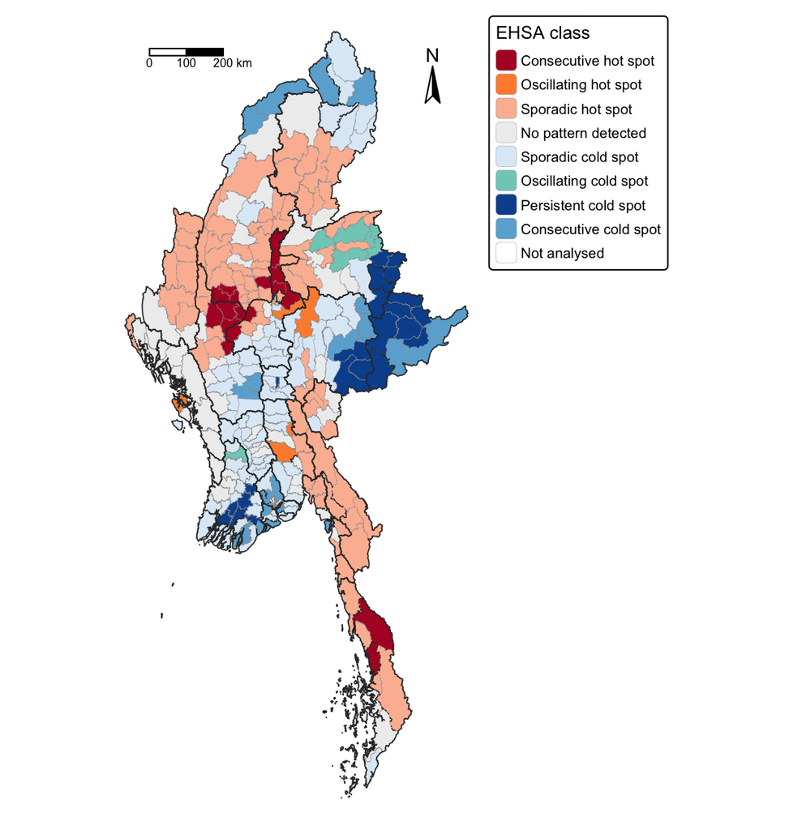

- Each township was tested in all 19 quarters: 108 have a hot-spot history, 166 a cold one and 55 no clear pattern.
- 17 consecutive hot spots: the Dry Zone core, its spread north and east of Mandalay, and Dawei and Palaw in Tanintharyi. Eleven have been hot every quarter since late 2021.
- No new, intensifying or persistent hot spot. The core was not yet hot in early 2021, before the armed uprising, so it falls just short of the 90% rule.
- 6 of the 7 oscillating cold spots are in the Kokang and Lashio area of northern Shan: hot during Operation 1027, cold by mid-2025.
- The Gi* trend is rising in 69 townships and falling in 81.

Exact labels are fragile (only 78% keep their class at threshold 0.025), but hot or cold is robust: 71 townships are hot and 121 cold in all six runs.

## 6 · Several wars, not one

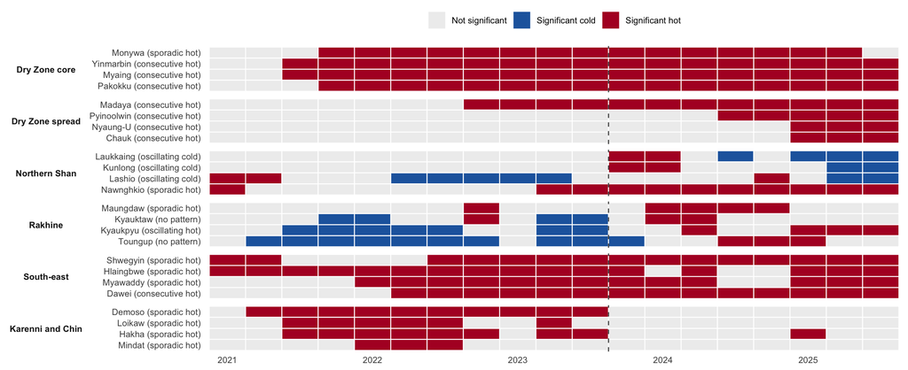

A core that keeps spreading. The Dry Zone core has been hot almost every quarter since late 2021, and the zone reached Pyinoolwin in 2024 and Nyaung-U and Chauk in 2025.

Short, intense fronts. Most of northern Shan was hot only in the two quarters around Operation 1027 (dashed line); only its western edge, such as Nawnghkio, stayed hot. Rakhine went from cold to hot in 2024, then quiet except Kyaukpyu.

Fronts that faded. Kayah and Chin were hot early and then dropped out. Kayah’s events truly fell; Chin was overtaken by fighting elsewhere.

## 7 · Air war follows ground war

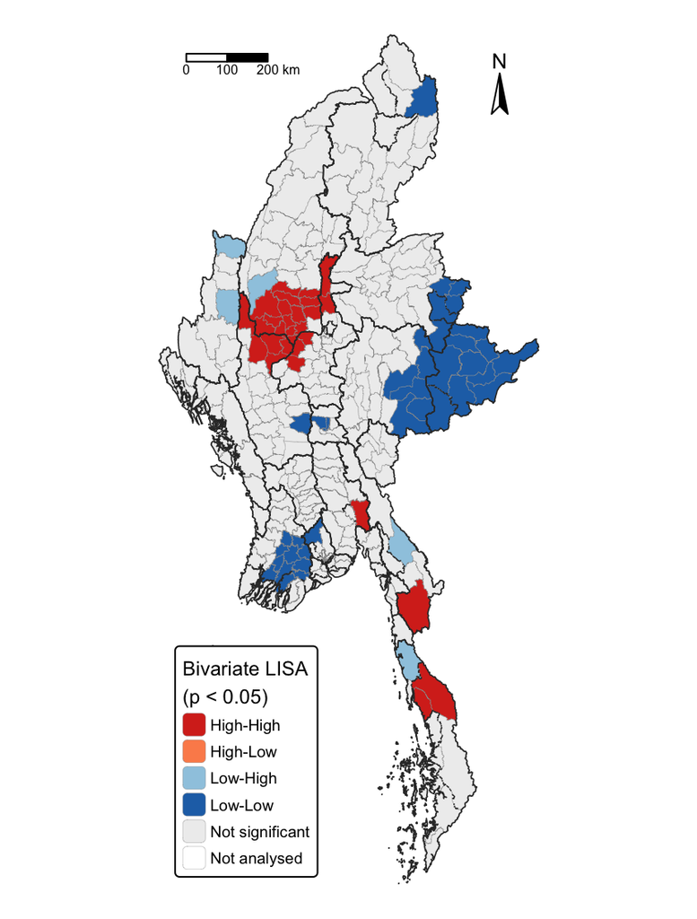

Do air and drone strikes fall where other fighting is, or apart from it?

- Global bivariate Moran’s I = 0.44 (p = 0.001): townships with many strikes sit among townships with much other fighting.
- 29 High-High townships, mostly in Sagaing, Magway and Mandalay, received 33% of all 7,911 strikes.
- 47 Low-Low, 43 of them with no strikes at all.
- No High-Low: no township is struck heavily while its surroundings are calm.
- 71% of strikes have state forces as first actor. Using only those keeps 24 of 29 High-High and all 47 Low-Low townships.

What this adds to LISA: the clusters were already known, but the air war is now shown not to be independent of the ground war. It shows co-location, not cause, and the 5 Low-High townships are weak results (one survives FDR).

## 8 · Limitations

- Reported events, not violence  
  ACLED depends on media and local reports. Where access is poor (the Wa hills, Rakhine during blackouts) counts understate conflict, so a cold spot means fewer events recorded, not less violence.
- Counts, not harm or rates  
  A skirmish and a massacre count once each, and the only population figures are from the 2014 census, before more than three million people were displaced.
- One fixed window  
  EHSA weights the final quarter (Q3 2025), so events after the window could change several classes.
- The unit shapes the result  
  Townships range from Yangon wards of a few km² to Shan townships of thousands; another boundary set could show a different pattern.
- Gi* is relative, labels are fragile  
  A township can lose hot status because fighting grew elsewhere. About half of LISA and Gi* results survive FDR, and EHSA classes are uncorrected.
- A modified EHSA  
  `sfdep` was corrected (position matching, pooled permutations, one mis-signed rule). It reproduces `sfdep`’s Gi* exactly but departs from the standard tool.
- No causal claims  
  Matching dates are consistent with a link but do not show one.

## 9 · Public-safety implications

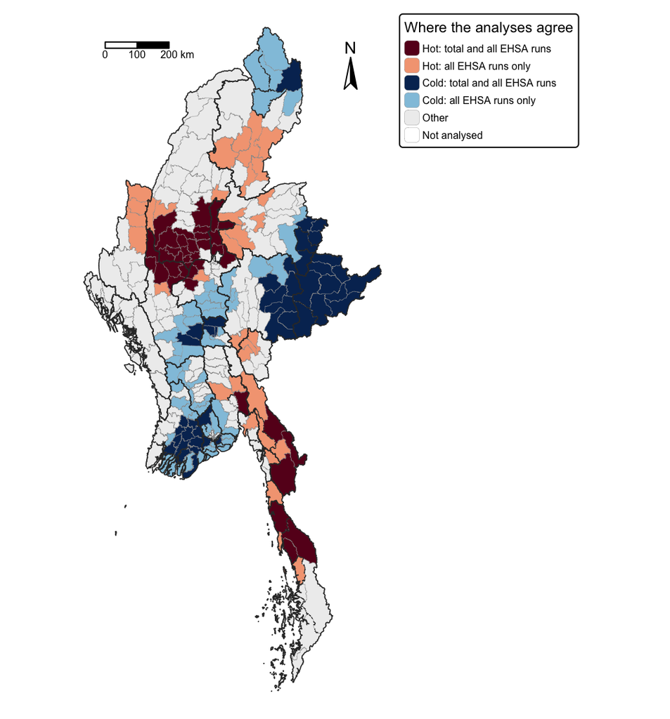

Supported directly by the analysis

- Plan for lasting hot spots, not only surges. The 71 townships hot in every EHSA run (dark and light red) hold 55% of all events and 11.2 million of the analysed townships’ 47.6 million people (2014 census): a baseline list for long-term protection and humanitarian access.
- Watch the edges of active fronts. Townships that turned hot recently and are still rising: Kyaukpyu, Pyinoolwin, Natogyi, Chauk, Nyaung-U. 3 have fewer than 130 events in total, so a map of totals would miss them.
- Prepare for ground and air attack together. Strikes follow the fighting, so civilians in hot spots face both: shelter, strike warning and medical access should assume both.
- Check ceasefires against data. During the 2025 earthquake ceasefires, events fell from 33.7 to 27.3 a day, but air and drone strikes went from 10.1 to 10.5 a day.

Motivated, but requiring further data

- Quiet is not safe. A cold spot may hide unreported fighting; quiet townships need other sources before any conclusion.
- Cause. Counts cannot show why fighting moves into a township, or whether a ceasefire caused a change rather than displacing it.
- Need. The 2014 population predates mass displacement (3.6 million internally displaced in 2025, OCHA); overlaying displacement and access data is the next step.

## Summary in one line

Myanmar’s 53,907 armed-conflict events since the coup centre on a Dry Zone core that has been hot almost every quarter since 2021 and is still spreading, while other fronts flared and faded. Air strikes follow the ground war, so the 71 townships hot in every run, holding 55% of all events, need a long-term protection posture, not a response to surges.